# Modelos Regresión Lineal para predecir el precio de viviendas

Minería de Datos y Modelización Predictiva

20/1/2020

## Introducción y esquema de trabajo

A lo largo de este documento se desarrolla el procedimiento básico para enfrentarse a un análisis de *Regresión Lineal* cuando los datos de entrada se encuentran previamente depurados. Se puede esquematizar el proceso como sigue:

1. Preparación de archivos y creación de variables aleatorias de control
2. Estudio descriptivo de relaciones de las variables
   - Relaciones de predictores con la variable objetivo
   - Relaciones entre los predictores
3. Tranformaciones de Variables para conseguir linealidad frente a la variable objetivo.
4. Análisis de modelos manuales de Regresión Lienal bajo el esquema training/test
   - Método hacia delante manual
   - Método hacia atrás manual
5. Comparación de los mejores modelos bajo el esquema de validación cruzada repetida.
6. Elección del modelo final
   - Evaluación
   - Interpretación

## Preámbulo y lectura de datos

En primer lugar fijaremos el directorio de trabajo en el que tenemos los datos y las funciones para, a continuación, cargar funciones y leer el conjunto de datos. En este documento, damos por depurado el archivo de entrada, ya que esta fase ya fue completada previamente.

```r
# Directorio de trabajo
setwd('C:/Users/Guille/Desktop/Master_Big_Data_Comercio_2020/Material para el campus/Matarial Campus Parte I')

# Cargo las funciones que voy a utilizar despu?s
source("Funciones_R.R")

# Cargo las librerias que me van a hacer falta (la función
# paquetes está en Funciones_R la ventaja es que instala el
# paquete en caso de necesidad)
paquetes(c('corrplot','caret','ggplot2','lmSupport','questionr','psych'))
# Lectura del archivo previamente depurado
datos<-readRDS("datosViviendaDep")
str(datos)
```

```
## 'data.frame':    5000 obs. of  19 variables:
##  $ varObjBin       : Factor w/ 2 levels "0","1": 2 2 2 2 1 1 1 2 1 2 ...
##  $ varObjCont      : num  653450 710000 780000 795000 399950 ...
##  $ year            : Factor w/ 2 levels "2014","2015": 1 1 1 1 1 1 1 1 1 1 ...
##  $ month           : num  7 6 10 12 10 6 7 6 6 7 ...
##  $ bedrooms        : Factor w/ 5 levels "0-1","2","3",..: 3 2 4 3 3 2 3 3 3 4 ...
##  $ bathrooms       : Factor w/ 6 levels "0","1","1.5",..: 5 3 6 6 4 2 5 5 4 6 ...
##  $ sqft_living     : num  2070 1640 3720 2260 2050 930 2000 3350 2000 5010 ...
##  $ sqft_lot        : num  2982 16200 33503 35120 6833 ...
##  $ floors          : Factor w/ 4 levels "1","1.5","2",..: 1 2 1 3 1 1 3 3 1 3 ...
##  $ waterfront      : Factor w/ 2 levels "0","1": 1 1 1 1 1 1 1 1 1 1 ...
##  $ view            : Factor w/ 2 levels "0","1": 1 1 2 1 1 1 1 1 1 2 ...
##  $ condition       : Factor w/ 4 levels "A","B","C","D": 3 1 2 2 1 2 3 2 3 2 ...
##  $ sqft_above      : num  1540 1540 3720 1880 1170 930 2000 2550 1300 4000 ...
##  $ basement        : Factor w/ 2 levels "0","1": 2 2 1 2 2 1 1 2 2 2 ...
##  $ yr_built        : num  1980 1916 2007 2003 1960 ...
##  $ lat             : num  47.6 47.7 47.3 47.6 47.7 ...
##  $ long            : num  -122 -122 -122 -122 -122 ...
##  $ yr_renovated_bin: Factor w/ 2 levels "0","1": 1 1 1 1 1 1 1 1 1 1 ...
##  $ prop_missings   : num  0.0625 0.0625 0.0625 0.0625 0.0625 0.0625 0.0625 0.0625 0.0625 0.0625 ...
```

Controlamos que no haya cosas raras de lectura de datos por si acaso. En este caso parece que todo es correcto.

**Nota**: En la fase de depuración previa, no es mala idea dejar las variables de naturaleza categórica en su estado original para poder recodificarla de otra forma (que la ya decidida) en caso de necesidad.

## Preparación de archivos de estudio y creación de variables aleatorias de control

En esta primera etepa separaremos las variables objetivo de los predictores de cara a la automatización del proceso de transformación de variables.

Un buen truco para evaluar la influencia o capacidad de discriminación de los predictores sobre las respuestas es la generación de variables aleatorias. Una variable aleatoria no debe tener influencia alguna sobre la variable objetivo, si se observa alguna relación puede ser espúrea o debida al puro azar. Teniendo esto en cuenta, si se observan predictores con menos capacidad de discriminación que las variables aleatorias generadas, sospecharemos que no es relevante para explicar la variabilidad de la variable objetivo.

```r
# Separo las variables objetivo y genero el archivo de características input
varObjCont<-datos$varObjCont
varObjBin<-datos$varObjBin
input<-datos[,-(1:2)]

# Creo la variable aleatoria
input$aleatorio<-runif(nrow(input))
input$aleatorio2<-runif(nrow(input))
```

## Análisis descriptivo de asociación entre pares de variables

Para tener una idea inicial de la infuencia de las variables predictoras sobre la respuesta, el primer paso es un análisis descriptivo de asociación entre variables.

En general,

- Relaciones nominal-nominal –> Análisis Chi-Cuadrado y su extensión V d Cramer
- Relaciones continua-continua –> Análisis de correlaciones. Posibilidad: Vcramer tramificando variables
- Relaciones continua-nominal –> Estudio de medias de la continua por grupos de la nominal(tpo ANOVA). Posibilidad de utilizar VCramer tramificando la continua

Hay que tener en cuenta que, cuando estudiamos la relación entre dos variables *cuantitativas* en términos de la correlación, las posibles relaciones **no lienales** no serán captadas adecuadamente.

Para poder intuir la existencia de estas relaciones no lineales se puede optar por transformar la variable (apartado de transformaciones) o bien discretizar la variable por tramos y realizar un estudio de tipo $\chi^2$/V de Cramer.

Recordemos por un momento que estos estadísticos están basados en la distribución de las frecuencias de una **tabla de contingencia** fruto del cruce entre dos variables nominales. Es por ello que carecen de orden lineal.

$$\chi^2=\sum_{i=1}^k\sum_{j=1}^l\frac{\left(n_{ij}-\frac{n_{i\cdot}n_{\cdot j}}{n}\right)^2}{\frac{n_{i\cdot}n_{\cdot j}}{n}}$$

Así, se comparan las distribuciones observadas de frecuecias en las casillas de la tabla y se comparan con las esperadas dadas las distribuciones marginales de cada una de las variables. Este análisis permite capturar relaciones no lienales entre variables cuantitativas y puede ser utilizado junto al análisis de correlación lineal y la tranformación de variables.

**Estadístico $\chi^2$**

El estadístico $\chi^2$ toma valor $0$ cuando las variables son **independientes** (no hay relación entre ellas). Matemáticamente esto equivale a decir que las frecuencias relativas de los cruces de categorías **sólo dependen** de las frecuencias relativas de las categorías:

$$f_{ij}=f_{i\cdot}f_{\cdot j}\text{, donde }f_{ij}=\frac{n_{ij}}{n}\quad f_{i\cdot}=\frac{n_{i\cdot}}{n} \quad f_{\cdot j}=\frac{n_{\cdot j}}{n}$$

Por lo tanto, las variables que estén fuertemente relacionadas tendrán un estadístico $\chi^2$ **alto**. Sin embargo, este estadístico no está limitado, por lo que resulta complicado determinar cuando está tomando un valor significativamente alto.

**Estadístico V de Cramer**

El estadístico V de Cramer está basado en el estadístico $\chi^2$ pero tiene la ventaja de que su valor está **acotado** entre $0$ y $1$. Viene dado por:

$$V=\sqrt{\frac{\chi^2}{n\times \min(l-1,k-1)}}$$

En este apartado vamos a estudiar las relaciones con las variables objetivo continua y binaria.

- La variable objetivo **continua** es nuestro *target* en **Regresión Lineal**
  - Predictores continuos
    - Visualizacion: Scatterplot/Nube de puntos.
    - Cuantificación: Correlaciones/Vcramer doble tramificado
  - Predictores categóricos
    - Visualizacion: Boxplot/Histograma.
    - Cuantificación: Diferencia de medias de target por grupos. Vcramer tramificando target.
- La variable obejtivo **binaria** es nuetro *target* en **Regresión Logística**
  - Predictores continuos
    - Visualizacion: Boxplot/Histograma (target binaria).
    - Cuantificación: Diferencia de medias por grupos. VCramer tramificando continua
  - Predictores categóricos
    - Visualizacion: Mosaico/Barras (target binaria).
    - Cuantificación: VCramer

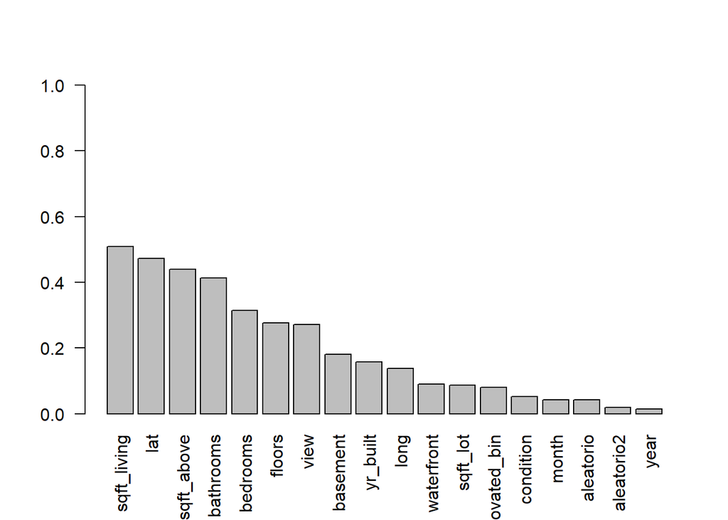

```r
#Obtengo la importancia de las variables. Falla si hay alguna
# variable cuantitativa con menos de 6 valores diferentes
graficoVcramer(input,varObjBin)
```

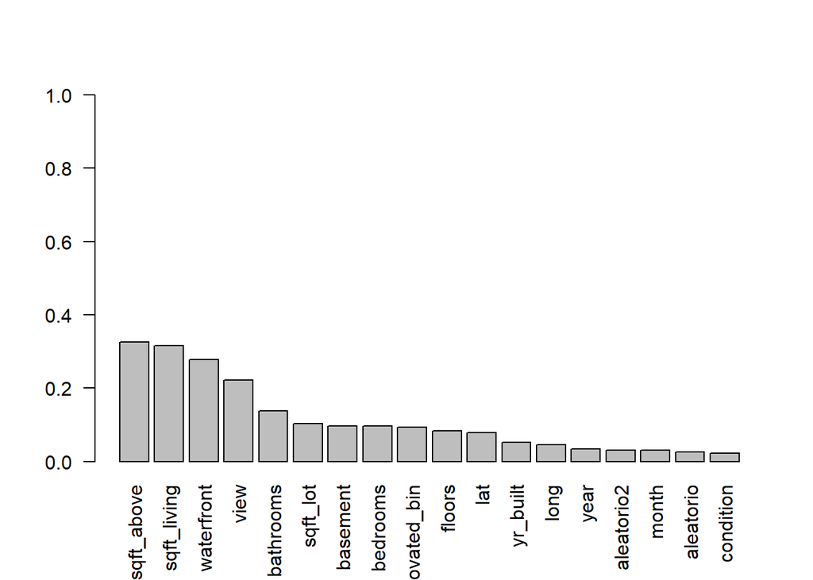

```r
graficoVcramer(input,varObjCont)
```

**Nota**: Es conveniente utilizar varios métodos para explorar la asociación entre variables.

Variables que parecen relevantes (bajo este criterio) para explicar la variable objetivo continua **Price**:

1. sqft_above
2. sqft_living
3. waterfront
4. view
5. bathrooms

Variables que parecen relevantes (bajo este criterio) para explicar la variable objetivo binaria **Luxury**:

1. sqft_living
2. lat
3. sqft_above
4. bathrooms
5. bedrooms

De alguna manera, ambas variables miden lo mismo ya que el lujo se encuentra estrechamente ligado al precio en casi todo, y así es en el mecado inmobiliario. Por tanto, no es descabellado pensar que los predictores relevantes bajo este criterio para una de ellas, puedan serlo también de la otra. No sería mala idea considerarlos para los modelos.

Seguidamente se muestran los gráficos de visualización de la posible influencia de los predictores categóricos sobre la variable objetivo binaria.

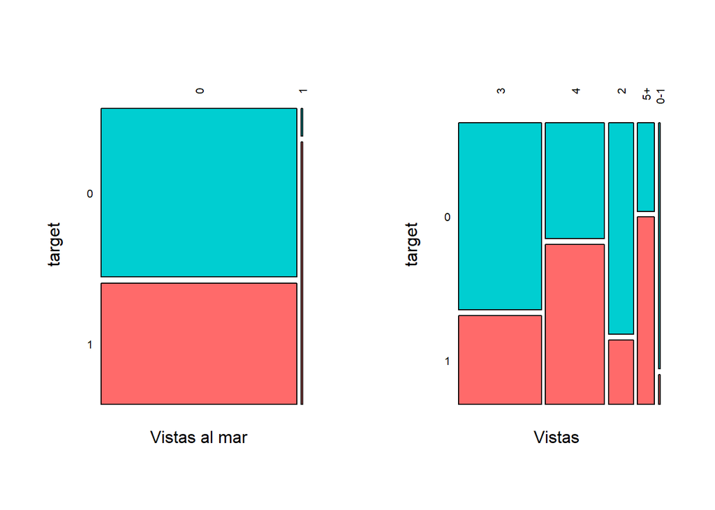

```r
#Veo gr?ficamente el efecto de dos variables cualitativas sobre la binaria
par(mfrow=c(1,2))
mosaico_targetbinaria(input$waterfront,varObjBin,"Vistas al mar") #esta influye
mosaico_targetbinaria(input$bedrooms,varObjBin,"Vistas") #esta influye
```

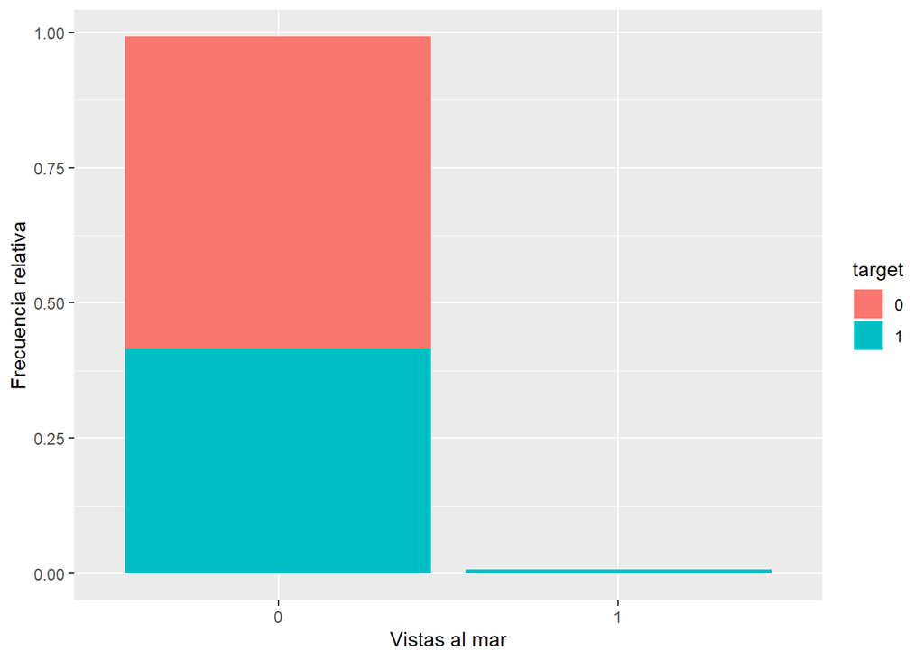

```r
barras_targetbinaria(input$waterfront,varObjBin,"Vistas al mar") #esta influye
```

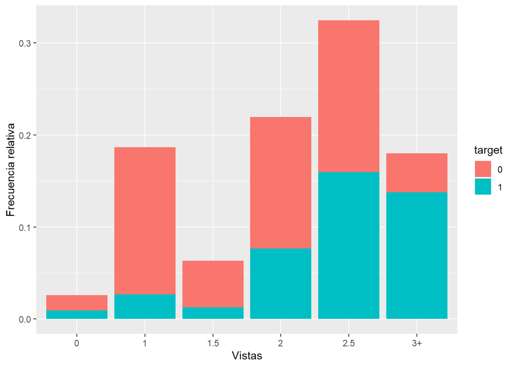

```r
barras_targetbinaria(input$bathrooms,varObjBin,"Vistas") #esta influye
```

Se puede observar que las distribuciones de las categorías de waterfront en las subpoblaciones de viviendas de lujo (variable objetivo binaria con valor 1) y las no consideradas de lujo (valor 0), presentan serias diferencias. Esto implica que se podría determinar el tipo de vivienda en función de los valores de esta variable. Este es el proceso de estudio para todas las variables.

En lo concerniente a variables continuas, se presentan los boxplot/histogramas para algunas de ellas.

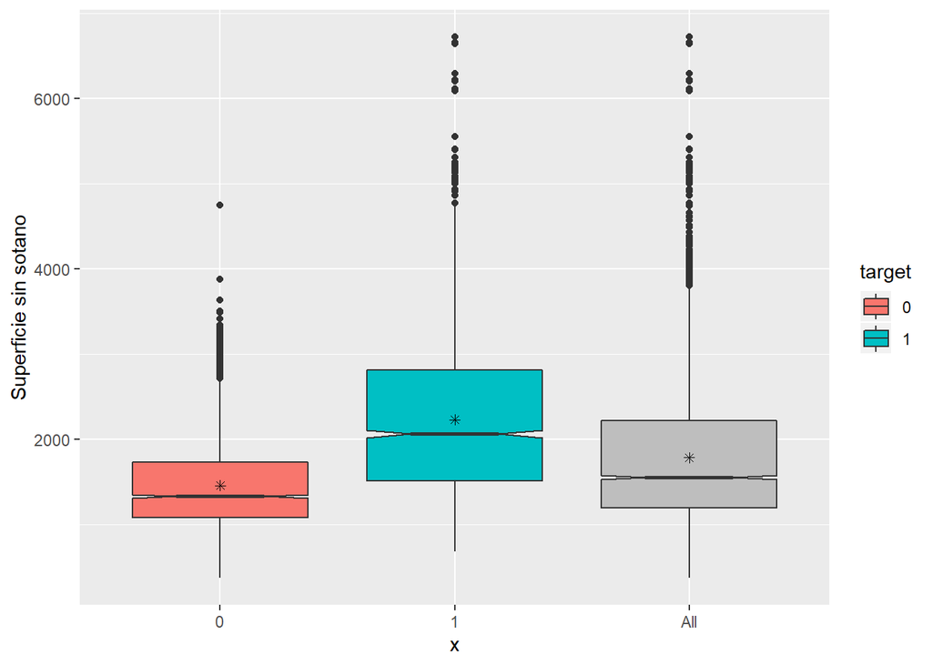

```r
#Veo gr?ficamente el efecto de dos variables cuantitativas sobre la binaria
boxplot_targetbinaria(input$sqft_above,varObjBin,"Superficie sin sotano")
```

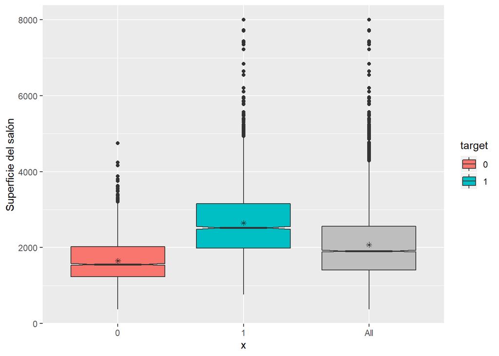

```r
boxplot_targetbinaria(input$sqft_living,varObjBin,"Superficie del salón")
```

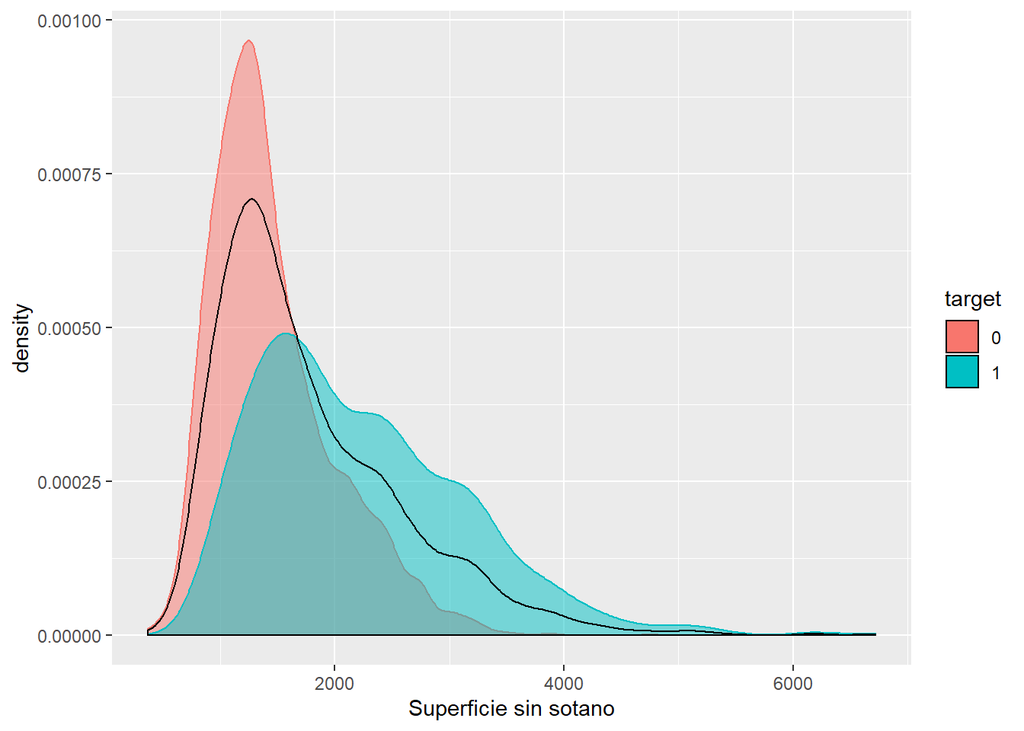

```r
hist_targetbinaria(input$sqft_above,varObjBin,"Superficie sin sotano")
```

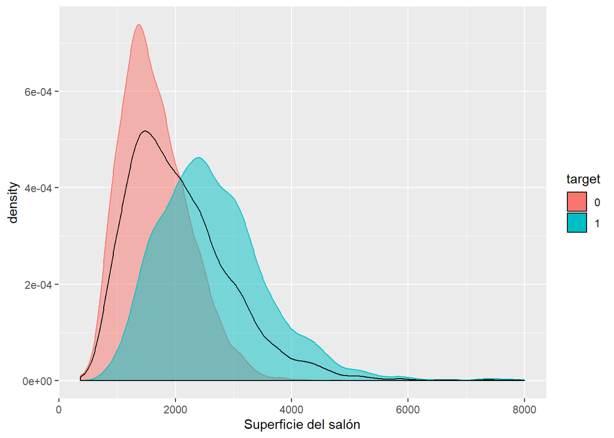

```r
hist_targetbinaria(input$sqft_living,varObjBin,"Superficie del salón")
```

Por último, es neceario realizar un estudio descriptivo y visual de las correlaciones entre variables continuas, en especial, las variable objetivo cuantitativa **price**.

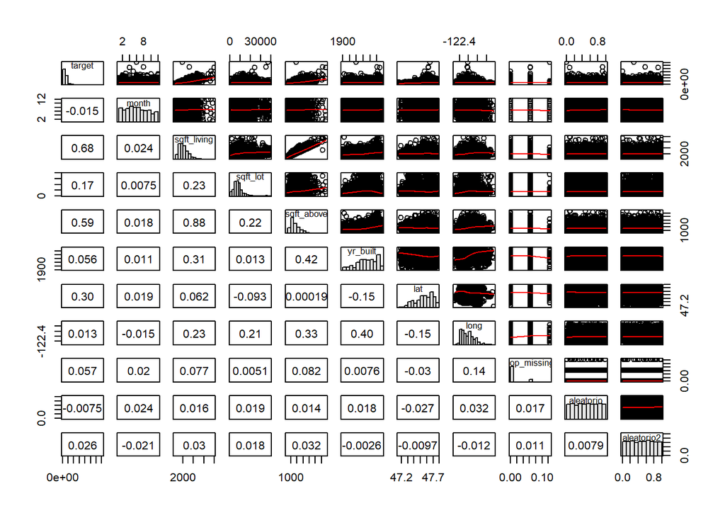

```r
#Todas las variables num?ricas frente a la objetivo continua
graficoCorrelacion(varObjCont,input) #Nos fijamos en la forma de las l?neas rojas
```

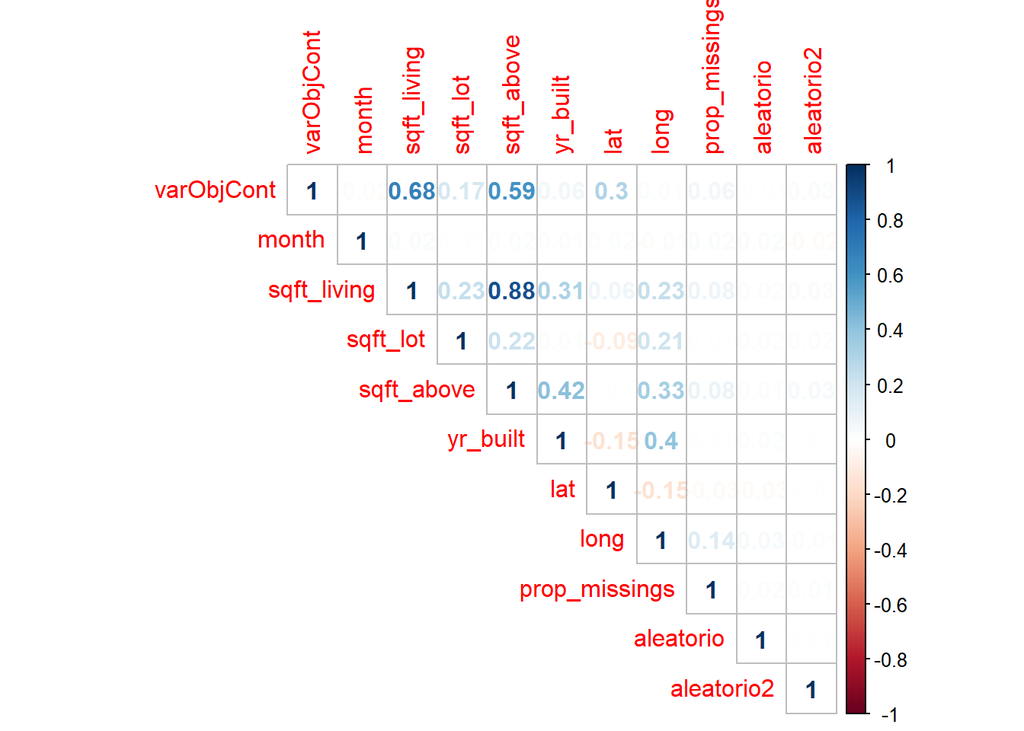

```r
# (si hay muchas variables num?ricas, tarda un poco)
corrplot(cor(cbind(varObjCont,Filter(is.numeric, input)), use="pairwise",
             method="pearson"), method = "number",type = "upper")
```

El análisis de correlación revela un ranking de relevancia de variables frente a **Price**:

1. sqft_living
2. sqft_above
3. lat
4. sqft_lot

Así mismo, salen a la luz ciertas relaciones lineales relevantes entre los propios predictores entre ellas,

1. sqft_living - sqft_above
2. sqft_avobe - year_built

Es posible que exita efecto de interacción entre las variables o de confusión entre ellas. Esto se puede refinar al buscar los modelos.

## Transformaciones de variables

En ocasiones, es posible *linealizar* la relación entre la variable objetivo y las input cuantitativas para que el modelo aproveche mejor el poder predictivo de éstas. Para ello, podemos transformar dichas variables eligiendo entre varias transformaciones aquella que maximice dicha relación, ya sea en términos del coeficiente de correlación (si la variable objetivo es cuantitativa) o de la V de Cramer (si la variable objetivo es cualitativa).

```r
#Busco las mejores transformaciones para las variables num?ricas con respesto a los dos tipos de variables
input_cont<-cbind(input,Transf_Auto(Filter(is.numeric, input),varObjCont))

# Cuento el número de valores diferentes para las numéricas
sapply(Filter(is.numeric, input)[,-ncol(Filter(is.numeric, input))],function(x) length(unique(x)))
```

```
##         month   sqft_living      sqft_lot    sqft_above      yr_built
##            12           568          2880           526           116
##           lat          long prop_missings     aleatorio
##          2985           600             3          5000
```

```r
input_bin<-cbind(input,Transf_Auto(Filter(is.numeric, input)[,-8],varObjBin)) # Quito proporción de
## missings que da problemas puesto que solo toma 3 valores distintos y está considerada como numérica.
## por aquello de la v de cramer y sus problemillas con este tipo de variables

## Guardar conjuntos de datos para regresión lineal y logística.
saveRDS(data.frame(input_bin,varObjBin),"todo_bin_V")
saveRDS(data.frame(input_cont,varObjCont),"todo_cont_v")
```

## Analisis exploratorio de modelos con el método train/test

```r
## Comienzo con la regresi?n lineal
todo<-data.frame(input,varObjCont)

#Obtengo la partici?n
set.seed(3465676)
trainIndex <- createDataPartition(todo$varObjCont, p=0.8, list=FALSE)
data_train <- todo[trainIndex,]
data_test <- todo[-trainIndex,]
```

Una vez genearados los conjuntos de *training* y *test*, se pueden seguir varias estrategias.

En primer lugar, partiendo de un modelo de regresión lineal completo con todas las variables originales, se valora el R2 ajustado y nuestro objetivo será simplificar el modelo al máximo sin perder mucha precisión. Para ello:

- Hacia delante: Empezar con las variables que parecen más relevantes en el análisis descriptivo y en el propio modelo. Una a una, viendo el posible efecto de interacción o confusión entre ellas (si al introducir una variable, el parámetro de una ya existente cambia significativamente, es posible que exista efecto cojunto)… Añadiremos efectos hasta que no se produzca mejora en las métricas (r2, AIC,BIC..)
- Hacia atras: Se van eliminando paulatinamente efectos no significativos en el modelo (teniendo en cuenta la información del estudio descriptivo), evaluando los cambios producidos en parámetros hasta llegar a una disminución significativa de las métricas de evaluación (r2, AIC,BIC..)

Es conveniente repetir el proceso con las variables continuas transformadas.

Ene ste caso vamos a desarrollar un proceso **hacia delante**.

```r
#Construyo un modelo preliminar con todas las variables
modeloCompleto<-lm(varObjCont~.,data=data_train)
summary(modeloCompleto)
```

```
##
## Call:
## lm(formula = varObjCont ~ ., data = data_train)
##
## Residuals:
##      Min       1Q   Median       3Q      Max
## -1002249  -107936    -9748    79475  5464598
##
## Coefficients:
##                     Estimate Std. Error t value Pr(>|t|)
## (Intercept)       -4.564e+07  4.314e+06 -10.580  < 2e-16 ***
## year2015           2.636e+04  1.288e+04   2.046 0.040835 *
## month             -1.855e+03  1.914e+03  -0.969 0.332386
## bedrooms2         -4.129e+04  3.976e+04  -1.038 0.299157
## bedrooms3         -9.342e+04  3.934e+04  -2.374 0.017623 *
## bedrooms4         -1.343e+05  4.022e+04  -3.340 0.000846 ***
## bedrooms5+        -1.185e+05  4.203e+04  -2.819 0.004835 **
## bathrooms1         1.663e+04  2.583e+04   0.644 0.519665
## bathrooms1.5      -4.151e+02  2.744e+04  -0.015 0.987931
## bathrooms2         1.458e+03  2.463e+04   0.059 0.952806
## bathrooms2.5       3.621e+03  2.450e+04   0.148 0.882484
## bathrooms3+        6.288e+04  2.597e+04   2.422 0.015499 *
## sqft_living        7.259e+01  1.704e+01   4.260 2.09e-05 ***
## sqft_lot           2.540e+00  7.173e-01   3.541 0.000403 ***
## floors1.5         -1.091e+04  1.506e+04  -0.724 0.468809
## floors2            1.091e+04  1.272e+04   0.858 0.391124
## floors2+           8.834e+04  2.270e+04   3.891 0.000101 ***
## waterfront1        5.415e+05  4.615e+04  11.733  < 2e-16 ***
## view1              1.747e+05  1.449e+04  12.055  < 2e-16 ***
## conditionB        -6.587e+04  1.534e+04  -4.295 1.79e-05 ***
## conditionC        -4.547e+04  1.554e+04  -2.925 0.003463 **
## conditionD        -1.866e+05  1.204e+05  -1.550 0.121222
## sqft_above         2.309e+02  1.888e+01  12.232  < 2e-16 ***
## basement1          1.180e+05  1.477e+04   7.989 1.76e-15 ***
## yr_built          -1.279e+03  2.094e+02  -6.107 1.11e-09 ***
## lat                6.429e+05  2.891e+04  22.240  < 2e-16 ***
## long              -1.441e+05  3.258e+04  -4.422 1.01e-05 ***
## yr_renovated_bin1  5.351e+04  2.028e+04   2.639 0.008356 **
## prop_missings      2.709e+05  1.624e+05   1.668 0.095456 .
## aleatorio         -8.292e+03  1.302e+04  -0.637 0.524376
## aleatorio2         1.240e+04  1.303e+04   0.952 0.341361
## ---
## Signif. codes:  0 '***' 0.001 '**' 0.01 '*' 0.05 '.' 0.1 ' ' 1
##
## Residual standard error: 237700 on 3970 degrees of freedom
## Multiple R-squared:  0.6026, Adjusted R-squared:  0.5996
## F-statistic: 200.7 on 30 and 3970 DF,  p-value: < 2.2e-16
```

```r
Rsq(modeloCompleto,"varObjCont",data_train)
```

```
## $r2
## [1] 0.6026232
##
## $r2_adj
## [1] 0.5995195
```

```r
Rsq(modeloCompleto,"varObjCont",data_test) #En test hay bastante diferencia, seguramente sobren variables
```

```
## $r2
## [1] 0.6820786
##
## $r2_adj
## [1] 0.6718867
```

```
## lm(formula = varObjCont ~ ., data = data_train)
##
## Coefficients
##                           SSR df pEta-sqr dR-sqr
## (Intercept)      6.321694e+12  1   0.0274     NA
## year             2.363950e+11  1   0.0011 0.0004
## month            5.307905e+10  1   0.0002 0.0001
## bedrooms         2.380235e+12  4   0.0105 0.0042
## bathrooms        1.596967e+12  5   0.0071 0.0028
## sqft_living      1.024890e+12  1   0.0046 0.0018
## sqft_lot         7.083253e+11  1   0.0031 0.0013
## floors           9.440360e+11  3   0.0042 0.0017
## waterfront       7.775532e+12  1   0.0335 0.0138
## view             8.207863e+12  1   0.0353 0.0145
## condition        1.169177e+12  3   0.0052 0.0021
## sqft_above       8.450714e+12  1   0.0363 0.0150
## basement         3.605138e+12  1   0.0158 0.0064
## yr_built         2.106618e+12  1   0.0093 0.0037
## lat              2.793595e+13  1   0.1108 0.0495
## long             1.104227e+12  1   0.0049 0.0020
## yr_renovated_bin 3.932350e+11  1   0.0018 0.0007
## prop_missings    1.570779e+11  1   0.0007 0.0003
## aleatorio        2.289358e+10  1   0.0001 0.0000
## aleatorio2       5.114322e+10  1   0.0002 0.0001
##
## Sum of squared errors (SSE): 224220137365142.2
## Sum of squared total  (SST): 564250727524675.2
```

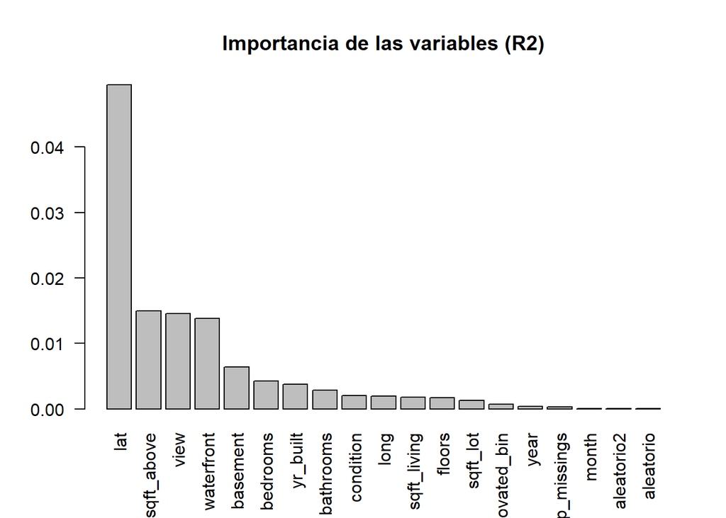

```r
# Nos fijamos en la importancia de las variables. Podemos sacar un gr?fico que muestra lo que se pierde en R2 en train al quitarlas del modelo
barplot(sort(modelEffectSizes(modeloCompleto)$Effects[-1,4],decreasing =T),las=2,main="Importancia de las variables (R2)")
```

```r
colnames(todo)
```

```
##  [1] "year"             "month"            "bedrooms"         "bathrooms"
##  [5] "sqft_living"      "sqft_lot"         "floors"           "waterfront"
##  [9] "view"             "condition"        "sqft_above"       "basement"
## [13] "yr_built"         "lat"              "long"             "yr_renovated_bin"
## [17] "prop_missings"    "aleatorio"        "aleatorio2"       "varObjCont"
```

```r
#[1] "year"             "month"            "bedrooms"         "bathrooms"        "sqft_living"
#[6] "sqft_lot"         "floors"           "waterfront"       "view"             "condition"
#[11] "sqft_above"       "basement"         "yr_built"         "lat"              "long"
#[16] "yr_renovated_bin" "prop_missings"    "aleatorio"        "aleatorio2"       "varObjCont"
```

En el modelo completo existen varios efectos no significativos. El valor de R2 nos sirve de referencia para evaluar la capacidad de los modelos más sencillos.

En el gráfico se puede observar el efecto sobre R2 de cada una de las variables en el modelo. Se observa una gran influencia de la variable *lat*. Parece tan impresionante que vamos a crear un modelo simple con ella.

```r
# Voy a ir poco a poco introduciendo variables
modelo0<-lm(varObjCont~lat,data=data_train)
summary(modelo0)
```

```
##
## Call:
## lm(formula = varObjCont ~ lat, data = data_train)
##
## Residuals:
##     Min      1Q  Median      3Q     Max
## -548484 -185398  -78032   76830 6446838
##
## Coefficients:
##              Estimate Std. Error t value Pr(>|t|)
## (Intercept) -38284795    1944649  -19.69   <2e-16 ***
## lat            816379      40887   19.97   <2e-16 ***
## ---
## Signif. codes:  0 '***' 0.001 '**' 0.01 '*' 0.05 '.' 0.1 ' ' 1
##
## Residual standard error: 358200 on 3999 degrees of freedom
## Multiple R-squared:  0.09066,    Adjusted R-squared:  0.09043
## F-statistic: 398.7 on 1 and 3999 DF,  p-value: < 2.2e-16
```

```r
Rsq(modelo0,"varObjCont",data_train) # Bastante pobre...
```

```
## $r2
## [1] 0.09065516
##
## $r2_adj
## [1] 0.09020026
```

```r
Rsq(modelo0,"varObjCont",data_test)
```

```
## $r2
## [1] 0.09086364
##
## $r2_adj
## [1] 0.08903806
```

Por si misma tiene efecto significativo pero explica muy poca variabilidad. Tal vez sea mejor empezar por otra variable relevante en términos de V de Cramer como *sqft_above*.

```r
# Voy a ir poco a poco introduciendo variables
modelo1<-lm(varObjCont~sqft_above,data=data_train)
summary(modelo1)
```

```
##
## Call:
## lm(formula = varObjCont ~ sqft_above, data = data_train)
##
## Residuals:
##     Min      1Q  Median      3Q     Max
## -856247 -168489  -41012  111983 6483300
##
## Coefficients:
##              Estimate Std. Error t value Pr(>|t|)
## (Intercept) 60835.115  11516.906   5.282 1.34e-07 ***
## sqft_above    269.982      5.858  46.091  < 2e-16 ***
## ---
## Signif. codes:  0 '***' 0.001 '**' 0.01 '*' 0.05 '.' 0.1 ' ' 1
##
## Residual standard error: 303600 on 3999 degrees of freedom
## Multiple R-squared:  0.3469, Adjusted R-squared:  0.3468
## F-statistic:  2124 on 1 and 3999 DF,  p-value: < 2.2e-16
```

```r
Rsq(modelo1,"varObjCont",data_train) # Bastante pobre...
```

```
## $r2
## [1] 0.3469286
##
## $r2_adj
## [1] 0.3466019
```

```r
Rsq(modelo1,"varObjCont",data_test)
```

```
## $r2
## [1] 0.3675198
##
## $r2_adj
## [1] 0.3662498
```

```r
# Ahora introducimos de nuevo lat
modelo2<-lm(varObjCont~lat+sqft_above,data=data_train)
summary(modelo2)
```

```
##
## Call:
## lm(formula = varObjCont ~ lat + sqft_above, data = data_train)
##
## Residuals:
##     Min      1Q  Median      3Q     Max
## -796593 -145205  -30442   83383 6411308
##
## Coefficients:
##               Estimate Std. Error t value Pr(>|t|)
## (Intercept) -3.863e+07  1.530e+06  -25.24   <2e-16 ***
## lat          8.135e+05  3.218e+04   25.28   <2e-16 ***
## sqft_above   2.697e+02  5.440e+00   49.59   <2e-16 ***
## ---
## Signif. codes:  0 '***' 0.001 '**' 0.01 '*' 0.05 '.' 0.1 ' ' 1
##
## Residual standard error: 281900 on 3998 degrees of freedom
## Multiple R-squared:  0.4369, Adjusted R-squared:  0.4367
## F-statistic:  1551 on 2 and 3998 DF,  p-value: < 2.2e-16
```

```r
Rsq(modelo2,"varObjCont",data_train) # Bastante pobre...
```

```
## $r2
## [1] 0.4369388
##
## $r2_adj
## [1] 0.4365162
```

```r
Rsq(modelo2,"varObjCont",data_test)
```

```
## $r2
## [1] 0.4608969
##
## $r2_adj
## [1] 0.4592715
```

```r
#Añado otra variable en orden de importancia
modelo3<-lm(varObjCont~lat+sqft_above+sqft_living,data=data_train)
summary(modelo3) ## Uy uy...huele a interacción!
```

```
##
## Call:
## lm(formula = varObjCont ~ lat + sqft_above + sqft_living, data = data_train)
##
## Residuals:
##     Min      1Q  Median      3Q     Max
## -787505 -126600  -22903   78841 6497603
##
## Coefficients:
##               Estimate Std. Error t value Pr(>|t|)
## (Intercept) -3.423e+07  1.439e+06 -23.790  < 2e-16 ***
## lat          7.192e+05  3.026e+04  23.768  < 2e-16 ***
## sqft_above   4.312e+01  1.056e+01   4.083 4.53e-05 ***
## sqft_living  2.357e+02  9.634e+00  24.464  < 2e-16 ***
## ---
## Signif. codes:  0 '***' 0.001 '**' 0.01 '*' 0.05 '.' 0.1 ' ' 1
##
## Residual standard error: 262900 on 3997 degrees of freedom
## Multiple R-squared:  0.5103, Adjusted R-squared:  0.5099
## F-statistic:  1388 on 3 and 3997 DF,  p-value: < 2.2e-16
```

```r
#El parámetro de la variable anterior deja de ser significativo..
Rsq(modelo3,"varObjCont",data_train)
```

```
## $r2
## [1] 0.510268
##
## $r2_adj
## [1] 0.5097778
```

```r
Rsq(modelo3,"varObjCont",data_test)
```

```
## $r2
## [1] 0.5900814
##
## $r2_adj
## [1] 0.5884318
```

```r
#Meto la interacción porque me da que va a tener efecto
modelo4<-lm(varObjCont~lat+sqft_above+sqft_living+sqft_above:sqft_living,data=data_train)
summary(modelo4) # Como se podía intuir...super significativa
```

```
##
## Call:
## lm(formula = varObjCont ~ lat + sqft_above + sqft_living + sqft_above:sqft_living,
##     data = data_train)
##
## Residuals:
##      Min       1Q   Median       3Q      Max
## -1405421  -113450   -21639    68001  6538355
##
## Coefficients:
##                          Estimate Std. Error t value Pr(>|t|)
## (Intercept)            -3.272e+07  1.403e+06 -23.319  < 2e-16 ***
## lat                     6.929e+05  2.949e+04  23.498  < 2e-16 ***
## sqft_above             -1.080e+02  1.435e+01  -7.528 6.35e-14 ***
## sqft_living             1.351e+02  1.150e+01  11.742  < 2e-16 ***
## sqft_above:sqft_living  5.104e-02  3.383e-03  15.088  < 2e-16 ***
## ---
## Signif. codes:  0 '***' 0.001 '**' 0.01 '*' 0.05 '.' 0.1 ' ' 1
##
## Residual standard error: 255800 on 3996 degrees of freedom
## Multiple R-squared:  0.5367, Adjusted R-squared:  0.5362
## F-statistic:  1157 on 4 and 3996 DF,  p-value: < 2.2e-16
```

```r
Rsq(modelo4,"varObjCont",data_train)
```

```
## $r2
## [1] 0.5366624
##
## $r2_adj
## [1] 0.5360825
```

```r
Rsq(modelo4,"varObjCont",data_test) # Mejora sustancial
```

```
## $r2
## [1] 0.6089631
##
## $r2_adj
## [1] 0.6069942
```

```r
# Introducimos otra variable
modelo42<-lm(varObjCont~lat+sqft_above+sqft_living+sqft_above:sqft_living+waterfront,data=data_train)
summary(modelo42) # Muy significativa
```

```
##
## Call:
## lm(formula = varObjCont ~ lat + sqft_above + sqft_living + sqft_above:sqft_living +
##     waterfront, data = data_train)
##
## Residuals:
##      Min       1Q   Median       3Q      Max
## -1298903  -111426   -18988    69503  5789880
##
## Coefficients:
##                          Estimate Std. Error t value Pr(>|t|)
## (Intercept)            -3.366e+07  1.360e+06 -24.751  < 2e-16 ***
## lat                     7.125e+05  2.858e+04  24.930  < 2e-16 ***
## sqft_above             -9.229e+01  1.393e+01  -6.626 3.92e-11 ***
## sqft_living             1.288e+02  1.115e+01  11.560  < 2e-16 ***
## waterfront1             7.466e+05  4.575e+04  16.320  < 2e-16 ***
## sqft_above:sqft_living  4.794e-02  3.282e-03  14.609  < 2e-16 ***
## ---
## Signif. codes:  0 '***' 0.001 '**' 0.01 '*' 0.05 '.' 0.1 ' ' 1
##
## Residual standard error: 247700 on 3995 degrees of freedom
## Multiple R-squared:  0.5656, Adjusted R-squared:  0.5651
## F-statistic:  1040 on 5 and 3995 DF,  p-value: < 2.2e-16
```

```r
Rsq(modelo42,"varObjCont",data_train)
```

```
## $r2
## [1] 0.5656216
##
## $r2_adj
## [1] 0.564969
```

```r
Rsq(modelo42,"varObjCont",data_test) # Mejora un poquito
```

```
## $r2
## [1] 0.6654695
##
## $r2_adj
## [1] 0.6634461
```

```r
# Introducimos otra variable
modelo5<-lm(varObjCont~lat+sqft_above+sqft_living+sqft_above:sqft_living+waterfront+view,data=data_train)
summary(modelo5) # Muy significativa
```

```
##
## Call:
## lm(formula = varObjCont ~ lat + sqft_above + sqft_living + sqft_above:sqft_living +
##     waterfront + view, data = data_train)
##
## Residuals:
##      Min       1Q   Median       3Q      Max
## -1347765  -106065   -17505    67631  5754770
##
## Coefficients:
##                          Estimate Std. Error t value Pr(>|t|)
## (Intercept)            -3.402e+07  1.325e+06 -25.668  < 2e-16 ***
## lat                     7.203e+05  2.785e+04  25.860  < 2e-16 ***
## sqft_above             -6.145e+01  1.374e+01  -4.473 7.92e-06 ***
## sqft_living             8.905e+01  1.120e+01   7.952 2.36e-15 ***
## waterfront1             5.756e+05  4.609e+04  12.487  < 2e-16 ***
## view1                   2.113e+05  1.446e+04  14.608  < 2e-16 ***
## sqft_above:sqft_living  4.766e-02  3.198e-03  14.903  < 2e-16 ***
## ---
## Signif. codes:  0 '***' 0.001 '**' 0.01 '*' 0.05 '.' 0.1 ' ' 1
##
## Residual standard error: 241400 on 3994 degrees of freedom
## Multiple R-squared:  0.5877, Adjusted R-squared:  0.587
## F-statistic: 948.7 on 6 and 3994 DF,  p-value: < 2.2e-16
```

```r
Rsq(modelo5,"varObjCont",data_train)
```

```
## $r2
## [1] 0.5876518
##
## $r2_adj
## [1] 0.586929
```

```r
Rsq(modelo5,"varObjCont",data_test) # Mejora un poquito
```

```
## $r2
## [1] 0.6901753
##
## $r2_adj
## [1] 0.6879868
```

```r
# Introducimos otra superficie en función de la latidud
modelo52<-lm(varObjCont~lat+sqft_above+sqft_living+sqft_above:sqft_living+waterfront+lat:sqft_above+view,data=data_train)
summary(modelo52) # Muy significativa y no hay cambio en los parámetros..no interacción
```

```
##
## Call:
## lm(formula = varObjCont ~ lat + sqft_above + sqft_living + sqft_above:sqft_living +
##     waterfront + lat:sqft_above + view, data = data_train)
##
## Residuals:
##      Min       1Q   Median       3Q      Max
## -1355072   -99858   -19325    67960  5754463
##
## Coefficients:
##                          Estimate Std. Error t value Pr(>|t|)
## (Intercept)            -1.332e+07  3.413e+06  -3.904 9.60e-05 ***
## lat                     2.850e+05  7.177e+04   3.971 7.27e-05 ***
## sqft_above             -1.184e+04  1.791e+03  -6.609 4.37e-11 ***
## sqft_living             9.338e+01  1.116e+01   8.368  < 2e-16 ***
## waterfront1             5.694e+05  4.586e+04  12.417  < 2e-16 ***
## view1                   2.123e+05  1.439e+04  14.755  < 2e-16 ***
## sqft_above:sqft_living  4.486e-02  3.209e-03  13.978  < 2e-16 ***
## lat:sqft_above          2.477e+02  3.767e+01   6.575 5.49e-11 ***
## ---
## Signif. codes:  0 '***' 0.001 '**' 0.01 '*' 0.05 '.' 0.1 ' ' 1
##
## Residual standard error: 240100 on 3993 degrees of freedom
## Multiple R-squared:  0.5921, Adjusted R-squared:  0.5914
## F-statistic: 827.9 on 7 and 3993 DF,  p-value: < 2.2e-16
```

```r
Rsq(modelo52,"varObjCont",data_train)
```

```
## $r2
## [1] 0.5920686
##
## $r2_adj
## [1] 0.5912511
```

```r
Rsq(modelo52,"varObjCont",data_test) # Mejora un poquito
```

```
## $r2
## [1] 0.6944474
##
## $r2_adj
## [1] 0.6919783
```

```r
# Introducimos las categóricas influyentes
modelo7<-lm(varObjCont~lat+sqft_above+sqft_living+sqft_above:sqft_living+waterfront+lat:sqft_above+view+bathrooms,data=data_train)
summary(modelo7) # Muy significativa y no hay cambio en los parámetros..no interacción
```

```
##
## Call:
## lm(formula = varObjCont ~ lat + sqft_above + sqft_living + sqft_above:sqft_living +
##     waterfront + lat:sqft_above + view + bathrooms, data = data_train)
##
## Residuals:
##      Min       1Q   Median       3Q      Max
## -1323300  -100525   -18503    68810  5708176
##
## Coefficients:
##                          Estimate Std. Error t value Pr(>|t|)
## (Intercept)            -1.357e+07  3.409e+06  -3.981 6.98e-05 ***
## lat                     2.904e+05  7.168e+04   4.051 5.19e-05 ***
## sqft_above             -1.147e+04  1.791e+03  -6.402 1.72e-10 ***
## sqft_living             7.901e+01  1.282e+01   6.164 7.81e-10 ***
## waterfront1             5.728e+05  4.580e+04  12.506  < 2e-16 ***
## view1                   2.090e+05  1.439e+04  14.527  < 2e-16 ***
## bathrooms1              5.828e+03  2.557e+04   0.228    0.820
## bathrooms1.5            5.431e+03  2.758e+04   0.197    0.844
## bathrooms2              1.555e+04  2.471e+04   0.629    0.529
## bathrooms2.5            1.484e+04  2.446e+04   0.607    0.544
## bathrooms3+             6.559e+04  2.579e+04   2.544    0.011 *
## sqft_above:sqft_living  4.520e-02  3.555e-03  12.715  < 2e-16 ***
## lat:sqft_above          2.399e+02  3.767e+01   6.368 2.13e-10 ***
## ---
## Signif. codes:  0 '***' 0.001 '**' 0.01 '*' 0.05 '.' 0.1 ' ' 1
##
## Residual standard error: 239600 on 3988 degrees of freedom
## Multiple R-squared:  0.5942, Adjusted R-squared:  0.5929
## F-statistic: 486.5 on 12 and 3988 DF,  p-value: < 2.2e-16
```

```r
Rsq(modelo7,"varObjCont",data_train)
```

```
## $r2
## [1] 0.594157
##
## $r2_adj
## [1] 0.5928337
```

```r
Rsq(modelo7,"varObjCont",data_test) # Mejora un poquito
```

```
## $r2
## [1] 0.6967681
##
## $r2_adj
## [1] 0.6927661
```

```r
# Hay que ver que pasa con esta..
modeloBath<-lm(varObjCont~bathrooms,data=data_train)
summary(modeloBath)
```

```
##
## Call:
## lm(formula = varObjCont ~ bathrooms, data = data_train)
##
## Residuals:
##     Min      1Q  Median      3Q     Max
## -649272 -174272  -50531   98058 6183228
##
## Coefficients:
##              Estimate Std. Error t value Pr(>|t|)
## (Intercept)    493256      32302  15.270  < 2e-16 ***
## bathrooms1    -148314      34536  -4.295 1.79e-05 ***
## bathrooms1.5   -92236      38119  -2.420   0.0156 *
## bathrooms2     -31725      34216  -0.927   0.3539
## bathrooms2.5    65377      33599   1.946   0.0518 .
## bathrooms3+    386015      34595  11.158  < 2e-16 ***
## ---
## Signif. codes:  0 '***' 0.001 '**' 0.01 '*' 0.05 '.' 0.1 ' ' 1
##
## Residual standard error: 332600 on 3995 degrees of freedom
## Multiple R-squared:  0.2169, Adjusted R-squared:  0.2159
## F-statistic: 221.3 on 5 and 3995 DF,  p-value: < 2.2e-16
```

```r
# Probaré alguna intetacción sobre esta
modelo8<-lm(varObjCont~lat+sqft_above+sqft_living+sqft_above:sqft_living+waterfront+lat:sqft_above+view+bathrooms+bathrooms:waterfront,data=data_train)
summary(modelo8) # Bastante significativas las interacciones..
```

```
##
## Call:
## lm(formula = varObjCont ~ lat + sqft_above + sqft_living + sqft_above:sqft_living +
##     waterfront + lat:sqft_above + view + bathrooms + bathrooms:waterfront,
##     data = data_train)
##
## Residuals:
##      Min       1Q   Median       3Q      Max
## -1395492  -100317   -19672    68698  5172808
##
## Coefficients: (1 not defined because of singularities)
##                            Estimate Std. Error t value Pr(>|t|)
## (Intercept)              -1.312e+07  3.370e+06  -3.894   0.0001 ***
## lat                       2.810e+05  7.086e+04   3.965 7.45e-05 ***
## sqft_above               -1.138e+04  1.771e+03  -6.427 1.46e-10 ***
## sqft_living               8.031e+01  1.266e+01   6.346 2.46e-10 ***
## waterfront1               1.116e+06  6.986e+04  15.970  < 2e-16 ***
## view1                     2.116e+05  1.420e+04  14.896  < 2e-16 ***
## bathrooms1                7.894e+03  2.524e+04   0.313   0.7545
## bathrooms1.5              7.022e+03  2.723e+04   0.258   0.7965
## bathrooms2                1.886e+04  2.439e+04   0.773   0.4394
## bathrooms2.5              1.562e+04  2.414e+04   0.647   0.5177
## bathrooms3+               5.740e+04  2.546e+04   2.254   0.0242 *
## sqft_above:sqft_living    4.504e-02  3.510e-03  12.831  < 2e-16 ***
## lat:sqft_above            2.381e+02  3.724e+01   6.392 1.82e-10 ***
## waterfront1:bathrooms1   -1.145e+06  1.534e+05  -7.463 1.03e-13 ***
## waterfront1:bathrooms1.5 -1.070e+06  2.470e+05  -4.333 1.50e-05 ***
## waterfront1:bathrooms2   -9.160e+05  1.051e+05  -8.719  < 2e-16 ***
## waterfront1:bathrooms2.5 -7.094e+05  1.266e+05  -5.605 2.22e-08 ***
## waterfront1:bathrooms3+          NA         NA      NA       NA
## ---
## Signif. codes:  0 '***' 0.001 '**' 0.01 '*' 0.05 '.' 0.1 ' ' 1
##
## Residual standard error: 236500 on 3984 degrees of freedom
## Multiple R-squared:  0.6051, Adjusted R-squared:  0.6036
## F-statistic: 381.6 on 16 and 3984 DF,  p-value: < 2.2e-16
```

```r
Rsq(modelo8,"varObjCont",data_train)
```

```
## $r2
## [1] 0.6051385
##
## $r2_adj
## [1] 0.6034532
```

```r
Rsq(modelo8,"varObjCont",data_test) # Mejora un poquito
```

```
## $r2
## [1] 0.6874258
##
## $r2_adj
## [1] 0.6820091
```

```r
# Introducimos otra variable
modelo9<-lm(varObjCont~lat+sqft_above+sqft_living+sqft_above:sqft_living+waterfront+lat:sqft_above+view+bathrooms+bathrooms:waterfront+sqft_lot,data=data_train)
summary(modelo9) # No es significativa..
```

```
##
## Call:
## lm(formula = varObjCont ~ lat + sqft_above + sqft_living + sqft_above:sqft_living +
##     waterfront + lat:sqft_above + view + bathrooms + bathrooms:waterfront +
##     sqft_lot, data = data_train)
##
## Residuals:
##      Min       1Q   Median       3Q      Max
## -1379551  -101160   -20787    67223  5134711
##
## Coefficients: (1 not defined because of singularities)
##                            Estimate Std. Error t value Pr(>|t|)
## (Intercept)              -1.385e+07  3.384e+06  -4.094 4.33e-05 ***
## lat                       2.962e+05  7.115e+04   4.164 3.20e-05 ***
## sqft_above               -1.114e+04  1.773e+03  -6.285 3.63e-10 ***
## sqft_living               7.630e+01  1.277e+01   5.973 2.53e-09 ***
## waterfront1               1.107e+06  6.992e+04  15.834  < 2e-16 ***
## view1                     2.109e+05  1.420e+04  14.853  < 2e-16 ***
## bathrooms1                4.591e+03  2.527e+04   0.182   0.8558
## bathrooms1.5              5.500e+03  2.722e+04   0.202   0.8399
## bathrooms2                1.714e+04  2.439e+04   0.703   0.4823
## bathrooms2.5              1.628e+04  2.413e+04   0.674   0.5001
## bathrooms3+               5.969e+04  2.547e+04   2.344   0.0191 *
## sqft_lot                  1.515e+00  6.735e-01   2.250   0.0245 *
## sqft_above:sqft_living    4.556e-02  3.516e-03  12.957  < 2e-16 ***
## lat:sqft_above            2.330e+02  3.729e+01   6.249 4.57e-10 ***
## waterfront1:bathrooms1   -1.152e+06  1.533e+05  -7.513 7.09e-14 ***
## waterfront1:bathrooms1.5 -1.090e+06  2.470e+05  -4.413 1.05e-05 ***
## waterfront1:bathrooms2   -9.077e+05  1.051e+05  -8.638  < 2e-16 ***
## waterfront1:bathrooms2.5 -7.143e+05  1.265e+05  -5.646 1.76e-08 ***
## waterfront1:bathrooms3+          NA         NA      NA       NA
## ---
## Signif. codes:  0 '***' 0.001 '**' 0.01 '*' 0.05 '.' 0.1 ' ' 1
##
## Residual standard error: 236400 on 3983 degrees of freedom
## Multiple R-squared:  0.6056, Adjusted R-squared:  0.604
## F-statistic: 359.8 on 17 and 3983 DF,  p-value: < 2.2e-16
```

```r
Rsq(modelo9,"varObjCont",data_train)
```

```
## $r2
## [1] 0.6056396
##
## $r2_adj
## [1] 0.603857
```

```r
Rsq(modelo9,"varObjCont",data_test) # No mejora ---> Fuera la variable
```

```
## $r2
## [1] 0.6882296
##
## $r2_adj
## [1] 0.6825032
```

```r
# Introducimos otra variable
modelo10<-lm(varObjCont~lat+sqft_above+sqft_living+sqft_above:sqft_living+waterfront+lat:sqft_above+view+bathrooms+bathrooms:waterfront+basement,data=data_train)
summary(modelo10) # Es significativa..pero enmascara el efecto principal de las superficies
```

```
##
## Call:
## lm(formula = varObjCont ~ lat + sqft_above + sqft_living + sqft_above:sqft_living +
##     waterfront + lat:sqft_above + view + bathrooms + bathrooms:waterfront +
##     basement, data = data_train)
##
## Residuals:
##      Min       1Q   Median       3Q      Max
## -1451103  -105083   -18498    68155  5073485
##
## Coefficients: (1 not defined because of singularities)
##                            Estimate Std. Error t value Pr(>|t|)
## (Intercept)              -1.254e+07  3.348e+06  -3.745 0.000183 ***
## lat                       2.677e+05  7.039e+04   3.803 0.000145 ***
## sqft_above               -1.118e+04  1.759e+03  -6.354 2.33e-10 ***
## sqft_living              -8.687e+00  1.727e+01  -0.503 0.615080
## waterfront1               1.123e+06  6.938e+04  16.184  < 2e-16 ***
## view1                     2.115e+05  1.410e+04  14.993  < 2e-16 ***
## bathrooms1                1.603e+04  2.509e+04   0.639 0.522846
## bathrooms1.5              5.239e+03  2.704e+04   0.194 0.846392
## bathrooms2                1.231e+04  2.424e+04   0.508 0.611583
## bathrooms2.5              6.517e+03  2.401e+04   0.271 0.786055
## bathrooms3+               4.400e+04  2.535e+04   1.736 0.082678 .
## basement1                 1.083e+05  1.442e+04   7.510 7.26e-14 ***
## sqft_above:sqft_living    4.281e-02  3.499e-03  12.234  < 2e-16 ***
## lat:sqft_above            2.361e+02  3.699e+01   6.385 1.92e-10 ***
## waterfront1:bathrooms1   -1.181e+06  1.524e+05  -7.752 1.14e-14 ***
## waterfront1:bathrooms1.5 -1.056e+06  2.453e+05  -4.304 1.72e-05 ***
## waterfront1:bathrooms2   -9.200e+05  1.043e+05  -8.817  < 2e-16 ***
## waterfront1:bathrooms2.5 -7.124e+05  1.257e+05  -5.668 1.55e-08 ***
## waterfront1:bathrooms3+          NA         NA      NA       NA
## ---
## Signif. codes:  0 '***' 0.001 '**' 0.01 '*' 0.05 '.' 0.1 ' ' 1
##
## Residual standard error: 234900 on 3983 degrees of freedom
## Multiple R-squared:  0.6107, Adjusted R-squared:  0.609
## F-statistic: 367.5 on 17 and 3983 DF,  p-value: < 2.2e-16
```

```r
Rsq(modelo10,"varObjCont",data_train)
```

```
## $r2
## [1] 0.6106517
##
## $r2_adj
## [1] 0.6088917
```

```r
Rsq(modelo10,"varObjCont",data_test)
```

```
## $r2
## [1] 0.6721216
##
## $r2_adj
## [1] 0.6660994
```

```r
# Se me ocurre que puede tener interaccion con la de superficie total que parecía no significativa
modelo11<-lm(varObjCont~lat+sqft_above+sqft_living+sqft_above:sqft_living+waterfront+lat:sqft_above+view+bathrooms+bathrooms:waterfront+basement*sqft_lot,data=data_train)
summary(modelo11) # Bastente interacción efectivamente!
```

```
##
## Call:
## lm(formula = varObjCont ~ lat + sqft_above + sqft_living + sqft_above:sqft_living +
##     waterfront + lat:sqft_above + view + bathrooms + bathrooms:waterfront +
##     basement * sqft_lot, data = data_train)
##
## Residuals:
##      Min       1Q   Median       3Q      Max
## -1424405  -102673   -18415    68759  4936926
##
## Coefficients: (1 not defined because of singularities)
##                            Estimate Std. Error t value Pr(>|t|)
## (Intercept)              -1.347e+07  3.355e+06  -4.015 6.04e-05 ***
## lat                       2.876e+05  7.054e+04   4.077 4.66e-05 ***
## sqft_above               -1.084e+04  1.758e+03  -6.167 7.66e-10 ***
## sqft_living              -2.368e+01  1.754e+01  -1.350   0.1771
## waterfront1               1.107e+06  6.933e+04  15.969  < 2e-16 ***
## view1                     2.092e+05  1.408e+04  14.857  < 2e-16 ***
## bathrooms1                1.108e+04  2.507e+04   0.442   0.6586
## bathrooms1.5              1.569e+03  2.699e+04   0.058   0.9536
## bathrooms2                9.529e+03  2.420e+04   0.394   0.6937
## bathrooms2.5              3.930e+03  2.396e+04   0.164   0.8697
## bathrooms3+               4.456e+04  2.531e+04   1.761   0.0784 .
## basement1                 7.410e+04  1.700e+04   4.358 1.35e-05 ***
## sqft_lot                 -3.013e-01  8.378e-01  -0.360   0.7192
## sqft_above:sqft_living    4.298e-02  3.499e-03  12.284  < 2e-16 ***
## lat:sqft_above            2.293e+02  3.696e+01   6.204 6.08e-10 ***
## waterfront1:bathrooms1   -1.191e+06  1.520e+05  -7.832 6.14e-15 ***
## waterfront1:bathrooms1.5 -1.032e+06  2.451e+05  -4.210 2.61e-05 ***
## waterfront1:bathrooms2   -9.141e+05  1.042e+05  -8.776  < 2e-16 ***
## waterfront1:bathrooms2.5 -7.163e+05  1.254e+05  -5.712 1.20e-08 ***
## waterfront1:bathrooms3+          NA         NA      NA       NA
## basement1:sqft_lot        5.162e+00  1.322e+00   3.906 9.55e-05 ***
## ---
## Signif. codes:  0 '***' 0.001 '**' 0.01 '*' 0.05 '.' 0.1 ' ' 1
##
## Residual standard error: 234300 on 3981 degrees of freedom
## Multiple R-squared:  0.6127, Adjusted R-squared:  0.6109
## F-statistic: 331.5 on 19 and 3981 DF,  p-value: < 2.2e-16
```

```r
Rsq(modelo11,"varObjCont",data_train)
```

```
## $r2
## [1] 0.6127469
##
## $r2_adj
## [1] 0.6108009
```

```r
Rsq(modelo11,"varObjCont",data_test)
```

```
## $r2
## [1] 0.6712875
##
## $r2_adj
## [1] 0.6645653
```

```r
# Metemos alguna mas
modelo12<-lm(varObjCont~lat+sqft_above+sqft_living+sqft_above:sqft_living+waterfront+lat:sqft_above+view+bathrooms+bathrooms:waterfront+basement*sqft_lot+bedrooms+floors,data=data_train)
summary(modelo12) # Bastente interacción efectivamente!
```

```
##
## Call:
## lm(formula = varObjCont ~ lat + sqft_above + sqft_living + sqft_above:sqft_living +
##     waterfront + lat:sqft_above + view + bathrooms + bathrooms:waterfront +
##     basement * sqft_lot + bedrooms + floors, data = data_train)
##
## Residuals:
##      Min       1Q   Median       3Q      Max
## -1413865  -102029   -18416    67468  4955421
##
## Coefficients: (1 not defined because of singularities)
##                            Estimate Std. Error t value Pr(>|t|)
## (Intercept)              -1.089e+07  3.384e+06  -3.218  0.00130 **
## lat                       2.333e+05  7.119e+04   3.277  0.00106 **
## sqft_above               -1.165e+04  1.761e+03  -6.619 4.10e-11 ***
## sqft_living              -8.617e+00  1.839e+01  -0.469  0.63943
## waterfront1               1.095e+06  6.927e+04  15.801  < 2e-16 ***
## view1                     2.032e+05  1.410e+04  14.410  < 2e-16 ***
## bathrooms1               -2.235e+03  2.534e+04  -0.088  0.92974
## bathrooms1.5             -6.725e+03  2.695e+04  -0.249  0.80299
## bathrooms2                9.316e+03  2.419e+04   0.385  0.70021
## bathrooms2.5              6.009e+03  2.408e+04   0.250  0.80296
## bathrooms3+               4.497e+04  2.538e+04   1.772  0.07653 .
## basement1                 7.753e+04  1.713e+04   4.525 6.21e-06 ***
## sqft_lot                  4.795e-01  8.638e-01   0.555  0.57883
## bedrooms2                 4.596e+03  3.898e+04   0.118  0.90615
## bedrooms3                -3.785e+04  3.879e+04  -0.976  0.32923
## bedrooms4                -5.196e+04  3.986e+04  -1.304  0.19243
## bedrooms5+               -4.747e+04  4.148e+04  -1.144  0.25256
## floors1.5                 5.836e+04  1.422e+04   4.105 4.12e-05 ***
## floors2                   3.443e+03  1.209e+04   0.285  0.77589
## floors2+                  5.657e+04  2.147e+04   2.635  0.00844 **
## sqft_above:sqft_living    4.057e-02  3.693e-03  10.985  < 2e-16 ***
## lat:sqft_above            2.465e+02  3.703e+01   6.657 3.17e-11 ***
## waterfront1:bathrooms1   -1.186e+06  1.516e+05  -7.822 6.62e-15 ***
## waterfront1:bathrooms1.5 -1.051e+06  2.444e+05  -4.300 1.75e-05 ***
## waterfront1:bathrooms2   -9.248e+05  1.040e+05  -8.892  < 2e-16 ***
## waterfront1:bathrooms2.5 -7.257e+05  1.250e+05  -5.804 6.96e-09 ***
## waterfront1:bathrooms3+          NA         NA      NA       NA
## basement1:sqft_lot        4.874e+00  1.326e+00   3.676  0.00024 ***
## ---
## Signif. codes:  0 '***' 0.001 '**' 0.01 '*' 0.05 '.' 0.1 ' ' 1
##
## Residual standard error: 233400 on 3974 degrees of freedom
## Multiple R-squared:  0.6162, Adjusted R-squared:  0.6137
## F-statistic: 245.4 on 26 and 3974 DF,  p-value: < 2.2e-16
```

```r
Rsq(modelo12,"varObjCont",data_train)
```

```
## $r2
## [1] 0.61623
##
## $r2_adj
## [1] 0.613622
```

```r
Rsq(modelo12,"varObjCont",data_test)
```

```
## $r2
## [1] 0.6757247
##
## $r2_adj
## [1] 0.6667078
```

```r
# Modelo propuesto por Manu en clase
modeloManu<-lm(varObjCont~sqft_above+sqft_living+waterfront+view +bathrooms+lat
             +lat*sqft_above,data=data_train)
summary(modeloManu) # Significativo en su mayoría
```

```
##
## Call:
## lm(formula = varObjCont ~ sqft_above + sqft_living + waterfront +
##     view + bathrooms + lat + lat * sqft_above, data = data_train)
##
## Residuals:
##     Min      1Q  Median      3Q     Max
## -918424 -105833  -16845   77495 5663894
##
## Coefficients:
##                  Estimate Std. Error t value Pr(>|t|)
## (Intercept)    -1.054e+07  3.469e+06  -3.040  0.00238 **
## sqft_above     -1.365e+04  1.819e+03  -7.504 7.56e-14 ***
## sqft_living     1.809e+02  1.020e+01  17.730  < 2e-16 ***
## waterfront1     5.952e+05  4.668e+04  12.750  < 2e-16 ***
## view1           2.080e+05  1.467e+04  14.173  < 2e-16 ***
## bathrooms1      5.172e+04  2.582e+04   2.003  0.04522 *
## bathrooms1.5    1.521e+04  2.812e+04   0.541  0.58864
## bathrooms2      1.310e+04  2.520e+04   0.520  0.60311
## bathrooms2.5   -1.757e+04  2.481e+04  -0.708  0.47892
## bathrooms3+     4.988e+04  2.627e+04   1.899  0.05764 .
## lat             2.213e+05  7.290e+04   3.036  0.00241 **
## sqft_above:lat  2.886e+02  3.823e+01   7.551 5.31e-14 ***
## ---
## Signif. codes:  0 '***' 0.001 '**' 0.01 '*' 0.05 '.' 0.1 ' ' 1
##
## Residual standard error: 244400 on 3989 degrees of freedom
## Multiple R-squared:  0.5777, Adjusted R-squared:  0.5765
## F-statistic: 496.1 on 11 and 3989 DF,  p-value: < 2.2e-16
```

```r
Rsq(modeloManu,"varObjCont",data_train)
```

```
## $r2
## [1] 0.5777053
##
## $r2_adj
## [1] 0.5764346
```

```r
Rsq(modeloManu,"varObjCont",data_test) # No tiene mala pinta
```

```
## $r2
## [1] 0.6828719
##
## $r2_adj
## [1] 0.6790123
```

Como resumen solicitamos una lista de los valores de R^2 ajustado en el conjunto de test.

```r
Rsq(modelo2,"varObjCont",data_test)
```

```
## $r2
## [1] 0.4608969
##
## $r2_adj
## [1] 0.4592715
```

```r
Rsq(modelo3,"varObjCont",data_test)
```

```
## $r2
## [1] 0.5900814
##
## $r2_adj
## [1] 0.5884318
```

```r
Rsq(modelo4,"varObjCont",data_test)
```

```
## $r2
## [1] 0.6089631
##
## $r2_adj
## [1] 0.6069942
```

```r
Rsq(modelo42,"varObjCont",data_test)
```

```
## $r2
## [1] 0.6654695
##
## $r2_adj
## [1] 0.6634461
```

```r
Rsq(modelo5,"varObjCont",data_test)
```

```
## $r2
## [1] 0.6901753
##
## $r2_adj
## [1] 0.6879868
```

```r
Rsq(modelo52,"varObjCont",data_test)
```

```
## $r2
## [1] 0.6944474
##
## $r2_adj
## [1] 0.6919783
```

```r
Rsq(modelo7,"varObjCont",data_test)
```

```
## $r2
## [1] 0.6967681
##
## $r2_adj
## [1] 0.6927661
```

```r
Rsq(modelo8,"varObjCont",data_test)
```

```
## $r2
## [1] 0.6874258
##
## $r2_adj
## [1] 0.6820091
```

```r
Rsq(modelo9,"varObjCont",data_test)
```

```
## $r2
## [1] 0.6882296
##
## $r2_adj
## [1] 0.6825032
```

```r
Rsq(modelo10,"varObjCont",data_test)
```

```
## $r2
## [1] 0.6721216
##
## $r2_adj
## [1] 0.6660994
```

```r
Rsq(modelo11,"varObjCont",data_test)
```

```
## $r2
## [1] 0.6712875
##
## $r2_adj
## [1] 0.6645653
```

```r
Rsq(modelo12,"varObjCont",data_test)
```

```
## $r2
## [1] 0.6757247
##
## $r2_adj
## [1] 0.6667078
```

```r
Rsq(modeloManu,"varObjCont",data_test)
```

```
## $r2
## [1] 0.6828719
##
## $r2_adj
## [1] 0.6790123
```

## Comparación de modelos por Validación Cruzada Repetida

Una vez generados los modelos manuales hasta observar una estabilización de las métricas de evaluación, se procede a compararlos por validación cruzada repetida (todos o los que se consideren mejores).

Este proceso de validación permite evitar el efecto de la semilla de inicialización en la construcción de las particiones *training/test*. Debido a la aleatoreidad de la partición, es posible que en ocasiones se consigan conjuntos de test muy representativos del training y no así en otras. Puede sucesder que se tengan en test ejemplos no cubiertos en test, por ejemplo cuando hay clases minoritarias, entre otros problemas.

Se divide el archivo en n partes iguales y se utilizan n-1 para construir el modelo y la restante para probarlo, repitiendo el proceso en todas las permutaciones. Así se obtienen n modelos. De nuevo, aunque con menor incidencia, puede seguir estando presente el efecto de la semilla de particion del conjunto. Para minimizarlo al másximo, se repite todo el proceso de partición-modelado mútliple k veces.

Así, se obtienen finalmente kxn modelos creados a partir de todas las observaciones y probados tambien en todas ellas pero no simultanemante. Se consiguen modelos más robustos ante pequeños cambios en los conjuntos de *training/test*.

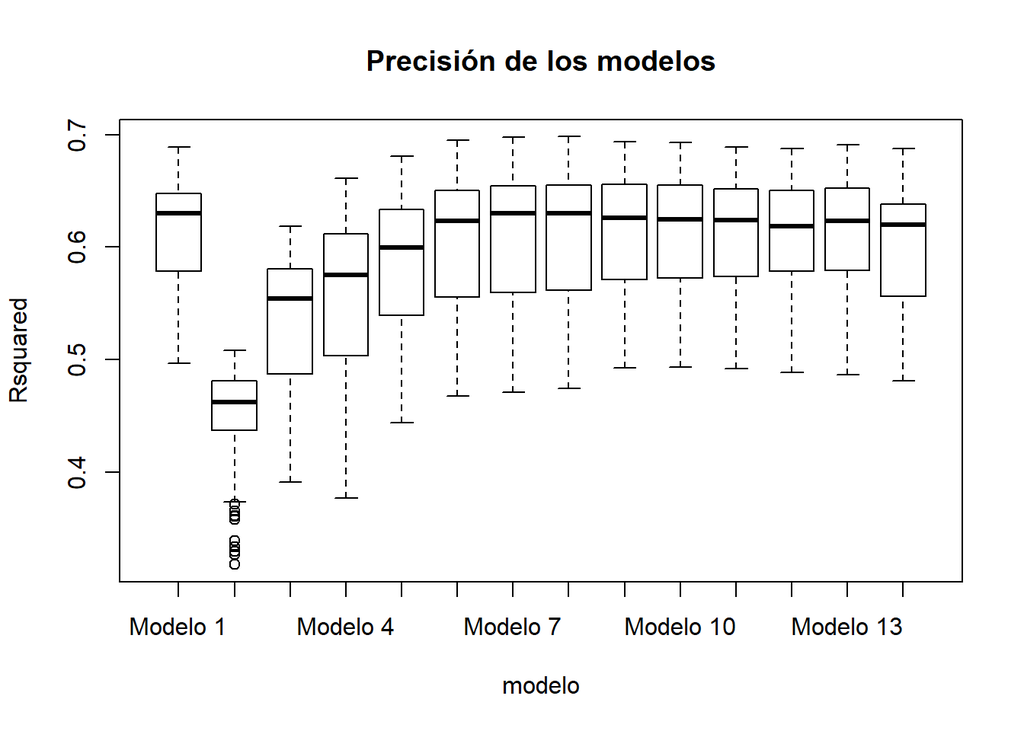

```r
# Validación cruzada repetida
total<-c()
modelos<-sapply(list(modeloCompleto,modelo2,modelo3,modelo4,modelo42,modelo5,modelo52,
                     modelo7,modelo8,modelo9,modelo10,modelo11,modelo12,modeloManu),formula)

for (i in 1:length(modelos)){
  set.seed(1712)
  vcr<-train(as.formula(modelos[[i]]), data = todo,
             method = "lm",
             trControl = trainControl(method="repeatedcv", number=5, repeats=20,returnResamp="all")
  )
  total<-rbind(total,data.frame(vcr$resample,modelo=rep(paste("Modelo",i),
                                                                nrow(vcr$resample))))
}
boxplot(Rsquared~modelo,data=total,main="Precisión de los modelos")
```

```r
aggregate(Rsquared~modelo, data = total, mean)
```

| modelo | Rsquared |
| --- | --- |
| Modelo 1 | 0.6124120 |
| Modelo 2 | 0.4483066 |
| Modelo 3 | 0.5332846 |
| Modelo 4 | 0.5556739 |
| Modelo 5 | 0.5849917 |
| Modelo 6 | 0.6077290 |
| Modelo 7 | 0.6118857 |
| Modelo 8 | 0.6128341 |
| Modelo 9 | 0.6139382 |
| Modelo 10 | 0.6136451 |

[output cut: 4 more lines]

```r
aggregate(Rsquared~modelo, data = total, sd) #muy similar
```

| modelo | Rsquared |
| --- | --- |
| Modelo 1 | 0.04843317 |
| Modelo 2 | 0.04621905 |
| Modelo 3 | 0.06247911 |
| Modelo 4 | 0.07039286 |
| Modelo 5 | 0.05902189 |
| Modelo 6 | 0.05782782 |
| Modelo 7 | 0.05788808 |
| Modelo 8 | 0.05668458 |
| Modelo 9 | 0.05180580 |
| Modelo 10 | 0.05098553 |

[output cut: 4 more lines]

```r
length(coef(modeloCompleto))
```

```
## [1] 31
```

```r
length(coef(modelo52))
```

```
## [1] 8
```

```r
length(coef(modelo8))
```

```
## [1] 18
```

```r
length(coef(modelo10))
```

```
## [1] 19
```

```r
length(coef(modelo12))
```

```
## [1] 28
```

```r
length(coef(modeloManu))
```

```
## [1] 12
```

Es todo cuestion de sesgo y varianza en primer lugar. Seleccionamos los de mejor relación y decidimos finalmente con el número de parámetros (cuanto menor, mejor).

En este caso parece adecuado quedarse ocn el modelo 52 ya que tiene una media muy similar a los modelos complejos con un poquito más de varianza pero sólamente 8 parámetros que estimar!!

## Interpretación y Evaluación del modelo ganador

Una vez decidido cual es el mejor modelo de entre los propuestos, el paso más importante es la la construcción de la función de predicción, la interpretación de los parámetros y sus efectos sobre la respuesta.

```r
# Vemos los coeficientes del modelo ganador
coef(modelo52)
```

```
##            (Intercept)                    lat             sqft_above
##          -1.332479e+07           2.850200e+05          -1.183626e+04
##            sqft_living            waterfront1                  view1
##           9.337572e+01           5.694340e+05           2.123238e+05
## sqft_above:sqft_living         lat:sqft_above
##           4.485927e-02           2.476806e+02
```

La expresión matemática del hiparplano de regresión para el modelo ganador es:

### Interpretación de parámetros.

Es muy importante saber interpretar el efecto de las variables sobre la respuesta. cada $\beta$ se interpreta en fución del tipo de variable que acompañe.

- Variable Cuantitativa: Por cada aumento unitario de la variable, la respuesta aumenta (+) o disminuye (-) en $\beta$ unidades)
- Varianle Binaria: La presencia de la característica (valor 1) aumenta o disminuye la respuesta en $\beta$ unidades

**Nota**: La **constante** del modelo **no** se puede interpretar como la **media** de la respuesta ya que está influenciada por la presencia de todas las demás variables y actúa como **ordenada en el origen** de la recta (hiperplano) de regresión. Eso quiere decir que la respuesta tomaría ese valor en caso de que todas las variables implicadas tomaran el valor 0 (Puede no darse el caso..)

Así se interprestarían los parámetros. En este caso parece extraña relación la de las superficies…se puede pensar en crear una variable que mida el efecto conjunto de ambas características como la variable superficie del salón en función de la superficie por encima del sótano…habría que probar esto.

```r
#Evaluamos la estabilidad del modelo a partir de las diferencias en train y test:
Rsq(modelo52,"varObjCont",data_train)
```

```
## $r2
## [1] 0.5920686
##
## $r2_adj
## [1] 0.5912511
```

```r
Rsq(modelo52,"varObjCont",data_test)
```

```
## $r2
## [1] 0.6944474
##
## $r2_adj
## [1] 0.6919783
```

```r
## Generamos los modelos por cv
set.seed(1712)
vcr<-train(as.formula(formula(modelo52)), data = todo,
             method = "lm",
             trControl = trainControl(method="repeatedcv", number=5, repeats=20,returnResamp="all"))

# Importancia de las variables en los múltiples modelos generado
# con caret. Esto nos da una idea de las más relevantes para interpretar
varImp(vcr)
```

```
## lm variable importance
##
##                          Overall
## view1                     100.00
## `sqft_above:sqft_living`   90.86
## waterfront1                88.19
## sqft_living                55.45
## sqft_above                 24.87
## `lat:sqft_above`           24.50
## lat                         0.00
```

## Otras posibilidades no contempladas

Es evidente que este no llega a ser un análisis completo de modelos pues no se han llegado a explorar cieryas posibilidades de mejora:

1. Estudio con variables transformadas
2. Cambio de niveles de referencia y, en su caso, ecategorización de variables categóricas con categorías no significativas
3. Tramificación de variables continuas
4. Dado el extraño efecto de sqft_above en consonancia con sqft_living, probar con la inclusión de una variable resultado de agregar ambas, por ejemplo un cociente que resulta facilmente interpretable.

Es posible que el efecto de las variables categóricas bedroom y bathrooms mejore al recategorizar/cambiar niveles de referencia.

Lo ideal sería probar el mayor número de posibilidades para intentar capturar de la forma más adecuada las relaciones subyacentes entre las variables que son capaces de modelizar la mayor parte del comportamiento (variabilidad) de la vairbale respuesta.